```python
import pandas as pd
import numpy as np
import matplotlib.pyplot as plt
import seaborn as sns
import plotly.express as px

plt.style.use('seaborn-white')
plt.rc('figure', dpi=100, figsize=(7, 5))
plt.rc('font', size=12)

import warnings
warnings.simplefilter('ignore')
```

# Lecture 28 – Fairness, Conclusion

## DSC 80, Spring 2022

### Announcements

- The Final Exam is on **tomorrow from 11:30AM-2:30PM in-person**!
  - See [this Campuswire post](https://campuswire.com/c/G325FA25B/feed/1754) for all the details, **including seating assignments and charts**.
  - Lectures 1-26, Projects 1-5, Labs 1-9, and Discussions 1-8 are all in scope.
  - [Come to office hours](https://dsc80.com/calendar/); I'm holding office hours from 5:30-7:30PM.
- Project 5 is due on **Thursday, June 9th at 11:59PM**!
- If at least 80% of the class fills out BOTH [CAPEs](https://cape.ucsd.edu/) and the [End-of-Quarter Survey](https://docs.google.com/forms/d/e/1FAIpQLSepSEBy0KC1-RHGF6dixYKZ-2p3SVdiPHB9spXPlA6PZNUy4A/viewform), then everyone will receive an extra 0.5% added to their overall course grade.
  - Deadline: **tomorrow at 8AM**.
  - Currently at ~60% on the internal survey and ~70% on CAPEs – we're close!
- The Grade Report is updated with everything other than Project 5 and the Final Exam.

### Agenda

- Fairness.
- Parity measures.
- Example: Loan approval.
- Parting thoughts.

## Fairness

### Example: Image searches

A 2015 study examined the image queries of vocations and the gender makeup in the search results. Since 2015, the behavior of Google Images has been improved.

In 2015, a Google Images search for "**nurse**" returned...

[figure not shown]

Search for "nurse" now, what do you see?

In 2015, a Google Images search for "**doctor**" returned...

[figure not shown]

Search for "doctor" now, what do you see?

### Ethics: What gender ratio *should* we expect in the results?

- Should it be 50/50?
- Should it reflect the true gender distribution of those jobs?
- More generally, what do you expect from your search results?
  - This is a philosophical and ethical question, but one that **we need to think about as data scientists**.

[figure not shown]

Excerpts:

> "male-dominated professions tend to have even more men in their results than would be expected if the proportions reflected real-world distributions.

> "People’s existing perceptions of gender ratios in occupations are quite accurate, but that manipulated search results have an effect on perceptions."

### How did this unequal representation occur?

- The training data that Google Images searches from encoded existing biases.
  - While 60% of doctors may be male, 80% of photos (including stock photos) of doctors on the internet may be of male doctors.
- Models (like PageRank) that "rank" images find the, say, 5 "most relevant" image, not the 5 "most typical" images.

## Parity measures

### Notation

- $C$ is a binary classifier.
  - $C \in \{0, 1\}$ is the prediction that the classifier makes.
  - For instance, $C$ may predict whether or not an assignment is plagiarized.
- $Y \in \{0,1\}$ is the "true" label.
- $A \in \{0, 1\}$ is a binary attribute of interest.
  - For instance, $A = 1$ may mean that you are a data science major, and $A = 0$ may mean that you are not a data science major.
- **Key idea:** A classifier $C$ is "fair" if it performs the same for individuals in group $A$ and individuals outside of group $A$.
  - But what do we mean by "the same"?

### Demographic parity

- A classifier $C$ achieves **demographic parity** if the proportion of the population for which $C = 1$ is the same both within A and outside A. $$\mathbb{P}(C=1|A=1) = \mathbb{P}(C=1|A\neq 1)$$
- The assumption of demographic parity: the proportion of times the classifier predicts 1 is **independent** of $A$.
- **Example 1:** $C$ is a binary classifier that predicts whether or not an essay is plagiarized.
  - Suppose $A$ is "class is a science class".
  - If $C$ achieves demographic parity, then **the proportion of the population for which an assignment is predicted to be plagiarized should be equal for science and non-science classes**.
- **Example 2:** $C$ is a binary classifier that predicts whether an image is of a doctor.
  - Suppose $A$ is "image is of a woman".
  - If $C$ achieves demographic parity, then **the proportion of the population for which the classification is "doctor" should be the same for women and non-women**.

### Accuracy parity

- Demographic parity is not the only notion of "fairness!"
  - You might expect more instances of plagiarism in non-science classes than you would in science classes; demographic parity says this is unfair but it may not be.
- A classifier $C$ achieves **accuracy parity** if the proportion of predictions that are classified correctly is the same both within $A$ and outside of $A$.

$$\mathbb{P}(C=Y|A=1) = \mathbb{P}(C=Y|A\neq 1)$$

- The assumption of accuracy parity: the classifier's accuracy should be independent of $A$.
- **Example:** $C$ is a binary classifier that determines whether someone receives a loan.
  - Suppose $A$ is "age is less than 25".
  - If the classifier is correct, i.e. if $C = Y$, then either $C$ approves the loan and it is paid off, or $C$ denies the loan and it would have defaulted.
  - If $C$ achieves accuracy parity, then the proportion of correctly classified loans should be the same for those under 25 and those over 25.

### True positive parity

- A classifier $C$ achieves **true positive parity** if the proportion of actually positive individuals that are correctly classified is the same both within $A$ and outside of $A$.

$$\mathbb{P}(C=1|Y=1, A=1) = \mathbb{P}(C=1|Y=1, A\neq 1)$$

- A more natural way to think of true positive parity is as **recall parity** – if $C$ achieves true positive parity, its recall should be independent of $A$.

### Other measures of parity

- We've just scratched the surface with measures of parity.
- Any evaluation metric for a binary classifier can lead to a parity measure – a parity measure requires "similar outcomes" across groups.
  - Precision parity.
  - False positive parity.
- **Note:** Many of these parity conditions are **impossible** to satisfy simultaneously!
  - See DSC 167 for more.

## Example: Loan approval

### LendingClub

LendingClub is a "peer-to-peer lending company"; they [used to publish](https://www.lendingclub.com/info/download-data.action) a dataset describing the loans that they approved (fortunately, we downloaded it while it was available).

- `'tag'`: whether loan was repaid in full (1.0) or defaulted (0.0)
- `'loan_amnt'`: amount of the loan in dollars
- `'emp_length'`: number of years employed
- `'home_ownership'`: whether borrower owns (1.0) or rents (0.0)
- `'inq_last_6mths'`: number of credit inquiries in last six months
- `'revol_bal'`: revolving balance on borrows accounts
- `'age'`: age in years of the borrower (protected attribute)

```python
loans = pd.read_csv('data/loan_vars1.csv', index_col=0)
loans.head()
```

|  | loan_amnt | emp_length | home_ownership | inq_last_6mths | revol_bal | age | tag |
| --- | --- | --- | --- | --- | --- | --- | --- |
| 268309 | 6400.0 | 0.0 | 1.0 | 1.0 | 899.0 | 22.0 | 0.0 |
| 301093 | 10700.0 | 10.0 | 1.0 | 0.0 | 29411.0 | 19.0 | 0.0 |
| 1379211 | 15000.0 | 10.0 | 1.0 | 2.0 | 9911.0 | 48.0 | 0.0 |
| 486795 | 15000.0 | 10.0 | 1.0 | 2.0 | 15883.0 | 35.0 | 0.0 |
| 1481134 | 22775.0 | 3.0 | 1.0 | 0.0 | 17008.0 | 39.0 | 0.0 |

The total amount of money loaned was over 5 billion dollars!

```python
loans['loan_amnt'].sum()
```

```
5706507225.0
```

```python
loans.shape[0]
```

```
386772
```

### Predicting `'tag'`

Let's build a classifier that predicts whether or not a loan was paid in full. If we were a bank, we could use our trained classifier to determine whether to approve someone for a loan!

```python
from sklearn.model_selection import train_test_split
from sklearn.ensemble import RandomForestClassifier
```

```python
X = loans.drop('tag', axis=1)
y = loans.tag
X_train, X_test, y_train, y_test = train_test_split(X, y)
```

```python
clf = RandomForestClassifier(n_estimators=50)
clf.fit(X_train, y_train)
```

```
RandomForestClassifier(n_estimators=50)
```

Recall, a prediction of 1 means that we predict that the loan will be paid in full.

```python
y_pred = clf.predict(X_test)
y_pred
```

```
array([0., 0., 0., ..., 0., 0., 0.])
```

```python
clf.score(X_test, y_test)
```

```
0.7125231402480015
```

```python
from sklearn import metrics
```

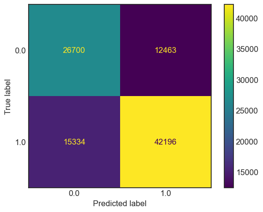

```python
metrics.plot_confusion_matrix(clf, X_test, y_test);
```

### Precision

$$\text{precision} = \frac{TP}{TP+FP}$$

Precision describes the **proportion of loans that were approved that would have been paid back**.

```python
metrics.precision_score(y_test, y_pred)
```

```
0.7719863151539545
```

If we subtract the precision from 1, we get the proportion of loans that were approved that **would not** have been paid back. This is known as the **false discovery rate**.

$$\frac{FP}{TP + FP} = 1 - \text{precision}$$

```python
1 - metrics.precision_score(y_test, y_pred)
```

```
0.22801368484604545
```

### Recall

$$\text{recall} = \frac{TP}{TP + FN}$$

Recall describes the **proportion of loans that would have been paid back that were actually approved**.

```python
metrics.recall_score(y_test, y_pred)
```

```
0.7334608030592734
```

If we subtract the recall from 1, we get the proportion of loans that would have been paid back that **were denied**. This is known as the **false negative rate**.

$$\frac{FN}{TP + FN} = 1 - \text{recall}$$

```python
1 - metrics.recall_score(y_test, y_pred)
```

```
0.2665391969407266
```

From both the perspective of the bank and the lendee, a high false negative rate is bad!

- The bank left money on the table – the lendee would have paid back the loan, but they weren't approved for a loan.
- The lendee deserved the loan, but weren't given one.

### False negative rate by age

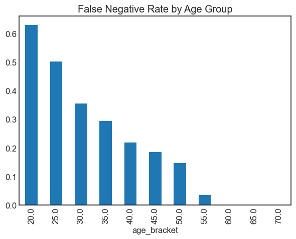

```python
results = X_test
results['age_bracket'] = results['age'].apply(lambda x: 5 * (x // 5 + 1))
results['prediction'] = y_pred
results['tag'] = y_test

(
    results
    .groupby('age_bracket')
    .apply(lambda x: 1 - metrics.recall_score(x['tag'], x['prediction']))
    .plot(kind='bar', title='False Negative Rate by Age Group')
);
```

### Computing parity measures

- $C$: Our random forest classifier (1 if we approved the loan, 0 if we denied it).
- $Y$: Whether or not they truly paid off the loan (1) or defaulted (0).
- $A$: Whether or not they were under 25 (1 if under, 0 if above).

```python
results['is_young'] = (results.age < 25).replace({True: 'young', False: 'old'})
```

First, let's compute the proportion of loans that were approved in each group. If these two numbers are the same, $C$ achieves demographic parity.

```python
results.groupby('is_young')['prediction'].mean().to_frame()
```

| is_young | prediction |
| --- | --- |
| old | 0.686767 |
| young | 0.298131 |

$C$ evidently does not achieve demographic parity – older people are approved for loans far more often! Note that this doesn't factor in whether they were *correctly* approved or *incorrectly* approved.

Now, let's compute the accuracy of $C$ in each group. If these two numbers are the same, $C$ achieves accuracy parity.

```python
(
    results
    .groupby('is_young')
    .apply(lambda x: metrics.accuracy_score(x['tag'], x['prediction']))
    .rename('accuracy')
    .to_frame()
)
```

| is_young | accuracy |
| --- | --- |
| old | 0.728456 |
| young | 0.677486 |

Hmm... These numbers look much more similar than before!

### Is this difference in accuracy significant?

Let's run a **permutation test** to see if the difference in accuracy is significant.

- Null Hypothesis: The classifier's accuracy is the same for both young people and old people, and any differences are due to chance.
- Alternative Hypothesis: The classifier's accuracy is higher for old people.
- Test statistic: Difference in accuracy (young minus old).
- Significance level: 0.01.

```python
obs = results.groupby('is_young').apply(lambda x: metrics.accuracy_score(x['tag'], x['prediction'])).diff().iloc[-1]
obs
```

```
-0.05097027305141033
```

```python
diff_in_acc = []
for _ in range(100):
    s = (
        results[['is_young', 'prediction', 'tag']]
        .assign(is_young=results.is_young.sample(frac=1.0, replace=False).reset_index(drop=True))
        .groupby('is_young')
        .apply(lambda x: metrics.accuracy_score(x['tag'], x['prediction']))
        .diff()
        .iloc[-1]
    )

    diff_in_acc.append(s)
```

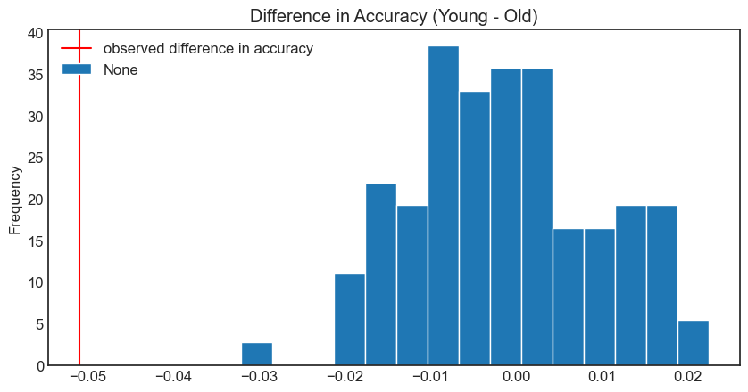

```python
plt.figure(figsize=(10, 5))
pd.Series(diff_in_acc).plot(kind='hist', ec='w', density=True, bins=15, title='Difference in Accuracy (Young - Old)')
plt.axvline(x=obs, color='red', label='observed difference in accuracy')
plt.legend(loc='upper left');
```

### Ethical questions of fairness

- **Question:** Is it "fair" to deny loans to younger people at a higher rate?
- One answer: yes!
  - Young people default more often.
  - To have same level of accuracy, we need to deny them loans more often.
- Other answer: no!
  - Accuracy isn't everything.
  - Younger people **need** loans to buy houses, pay for school, etc.
  - The bank should be required to take on higher risk; this is the cost of operating in a society.
- Federal law prevents age from being used as a determining factor in denying a loan.

Not only should we use `'age'` to determine whether or not to approve a loan, but we also shouldn't use other features that are strongly correlated with `'age'`, like `'emp_length'`.

```python
loans
```

|  | loan_amnt | emp_length | home_ownership | inq_last_6mths | revol_bal | age | tag |
| --- | --- | --- | --- | --- | --- | --- | --- |
| 268309 | 6400.0 | 0.0 | 1.0 | 1.0 | 899.0 | 22.0 | 0.0 |
| 301093 | 10700.0 | 10.0 | 1.0 | 0.0 | 29411.0 | 19.0 | 0.0 |
| 1379211 | 15000.0 | 10.0 | 1.0 | 2.0 | 9911.0 | 48.0 | 0.0 |
| 486795 | 15000.0 | 10.0 | 1.0 | 2.0 | 15883.0 | 35.0 | 0.0 |
| 1481134 | 22775.0 | 3.0 | 1.0 | 0.0 | 17008.0 | 39.0 | 0.0 |
| ... | ... | ... | ... | ... | ... | ... | ... |
| 466121 | 5000.0 | 1.0 | 0.0 | 0.0 | 8905.0 | 23.0 | 1.0 |
| 1354376 | 2100.0 | 10.0 | 1.0 | 0.0 | 14740.0 | 38.0 | 1.0 |
| 1150493 | 5000.0 | 1.0 | 1.0 | 0.0 | 3842.0 | 52.0 | 1.0 |
| 686485 | 6000.0 | 10.0 | 0.0 | 0.0 | 6529.0 | 36.0 | 1.0 |
| 342901 | 15000.0 | 8.0 | 1.0 | 1.0 | 16060.0 | 39.0 | 1.0 |

386772 rows × 7 columns

## Parting thoughts

[figure not shown]

### Course goals ✅

In this course, you...

- **Practiced** translating potentially vague questions into quantitative questions about measurable observations.
- **Learned** to reason about 'black-box' processes (e.g. complicated models).
- **Understood** computational and statistical implications of working with data.
- **Learned** to use real data tools (e.g. love the documentation!).
- **Got** a taste of the "life of a data scientist".

### Course outcomes ✅

Now, you...

- Are **prepared** for internships and data science "take home" interviews!
- Are **ready** to create your own portfolio of personal projects.
  - Side note: look at rampure.org/find-datasets to find datasets for personal projects.
- Have the **background** and **maturity** to succeed in the upper-division.

### Topics covered ✅

We learnt a lot this quarter.

- Week 1: DataFrames in `pandas`
- Week 2: Messy Data and Hypothesis Testing
- Week 3: Combining Data
- Week 4: Permutation Testing and Missing Values
- Week 5: Imputation, **Midterm Exam**
- Week 6: Web Scraping and Regex
- Week 7: Feature Engineering
- Week 8: Modeling in `scikit-learn`
- Week 9: Model Evaluation
- Week 10: Review, **Final Exam**

### Thank you!

This course would not have been possible without:

- Our TA: Murali Dandu.
- Our 11 tutors: Nicole Brye, Aven Huang, Shubham Kaushal, Karthikeya Manchala, Yash Potdar, Costin Smiliovici, Anjana Sriram, Ruojia Tao, Du Xiang, Sheng Yang, and Winston Yu.
- Don't be a stranger: dsc80.com/staff.
- **Apply to be a tutor in the future!** [Learn more here](https://datascience.ucsd.edu/academics/undergraduate/dsc-tutors/).

### Good luck on the Final Exam, and enjoy your summer! 🎉